# index

# 4. Kapitola - Fyzicke priklady parnych funkcii

## Priklad #1

Musime este spomenut aj *fyzicke* priklady pre parne funkcii,lebo matematika a fyzika su tesne spojite vypoctami a vyjadrenim nejakych vzorcov s pomocoh funkcii.

Napriklad,ako **potencialova energia pruziny:**
$$\frac{kx^2}{2}$$
. Graf,ako mozno vsimnut,kvoli argumentu $x^2$ bude parabola.

## Priklad #2

Mozeme vyskumat aj nieco zlozitejsie,ako *intenzita difrakcneho obrazca* z casti fiziky *optika:*

$$I(\theta) =
I_0(\frac{sin(\beta)}{\beta})^2,$$
kde $\beta = \frac{\pi a sin(\theta)}{\lambda}$

(Skusil som nejako vyjadrit graf,hladajuc vsetky hodnoty v internete,takze uzrite :-P)

### Graf:

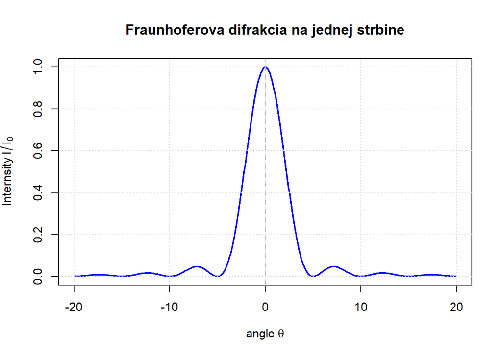

```r
lambda <- 500e-9
a <- 0.1e-3
theta <- seq(-0.02, 0.02, length.out = 500)


beta <- (pi * a * sin(theta)) / lambda


I <- (sin(beta) / beta)^2
I[is.na(I)] <- 1


plot(theta * 1000, I, type = "l", col = "blue", lwd = 2,
     xlab = expression("angle " * theta),
     ylab = expression("Internsity " * I / I[0]),
     main = "Fraunhoferova difrakcia na jednej strbine")
abline(v = 0, col = "gray", lty = 2, lwd = 1.5)
grid()
```

Gaussova funkcia v optike *(distribucia intenzity laseroveho luca):*
$$I(r) = I_0
e^\frac{-2r^2}{w_0^2},$$
kde $r = \sqrt{x^2+y^2}$ - vzdialenost od osi. Vzdlz $x$ (pre $y=0$) toto $I(x) = e^{-2x^2/w_0^2}$ je **parna funkcia**.

# 5. Zaver

*V projekte sme ukazali:*

Definiciu parnych funkcii s tabulkou prikladov

Integraciu na symetrickom intervale s explicitnym riesenim

Derivaciu párnej funkcie (vysledok je neparny)

Fourierove rady - parne funkcie obsahuju len kosinusy

Obsah plochy a jej rovnost z oboch stran grafu

## Zhrnutie:

```r
summary_df <- data.frame(
  vlatnosti = c("Symetria", "Integracia", "Derivacia", "Fourierov rad","Plocha"),
  vzorce = c("$f(-x) = f(x)$", "$\\int_{-a}^{a} f(x)dx = 2\\int_0^a f(x)dx$",
             "$f'(x)$ je neparna", "$b_n = 0$ (len kosinusy)","plocha na $[-a,0]$ = plocha na $[0,a]$")
)

kable(summary_df, caption = "Zhrnutie vlastnosi parnych funkcii",
      booktabs = TRUE, align = "c")
```

Zhrnutie vlastnosi parnych funkcii

| vlatnosti | vzorce |
| --- | --- |
| Symetria | $f(-x) = f(x)$ |
| Integracia | $\int_{-a}^{a} f(x)dx = 2\int_0^a f(x)dx$ |
| Derivacia | $f'(x)$ je neparna |
| Fourierov rad | $b_n = 0$ (len kosinusy) |
| Plocha | plocha na $[-a,0]$ = plocha na $[0,a]$ |